# Report-statistical analysis

2026-11-20

## Background

```r
library(nhanesA)
library(dplyr)
```

```r
library(ggplot2)

# 1. Download datasets
bpx <- nhanes("BPX_J")
smq <- nhanes("SMQ_J")
demo <- nhanes("DEMO_J")

# 2. Merge and prepare data

df <- demo %>%
  select(SEQN, RIDAGEYR) %>%
  inner_join(
    smq %>% select(SEQN, SMQ020),
    by = "SEQN"
  ) %>%
  inner_join(
    bpx %>% select(SEQN, BPXSY1, BPXSY2, BPXSY3),
    by = "SEQN"
  ) %>%
  mutate(
    smoking_response = as.character(SMQ020),
    smoking = case_when(
      smoking_response %in% c("1", "Yes") ~ "Ever-smokers",
      smoking_response %in% c("2", "No") ~ "Never-smokers",
      TRUE ~ NA_character_
    ),
    across(
      c(BPXSY1, BPXSY2, BPXSY3),
      ~ as.numeric(as.character(.x))
    ),
    mean_sbp = rowMeans(
      pick(BPXSY1, BPXSY2, BPXSY3),
      na.rm = TRUE
    )
  ) %>%
  filter(
    RIDAGEYR >= 20,
    !is.na(smoking),
    is.finite(mean_sbp),
    mean_sbp > 0
  )

# Check results
nrow(df)
```

```
## [1] 4996
```

```r
table(df$smoking)
```

```
##
##  Ever-smokers Never-smokers
##          2120          2876
```

```r
df %>%
  group_by(smoking) %>%
  summarise(
    n = n(),
    mean_sbp = mean(mean_sbp),
    median_sbp = median(mean_sbp),
    sd_sbp = sd(mean_sbp),
    .groups = "drop"
  )
```

```
## # A tibble: 2 × 5
##   smoking           n mean_sbp median_sbp sd_sbp
##   <chr>         <int>    <dbl>      <dbl>  <dbl>
## 1 Ever-smokers   2120     128.       128.     NA
## 2 Never-smokers  2876     126.       126.     NA
```

```r
# 3. Calculate descriptive summaries

summary_table <- df %>%
  group_by(smoking) %>%
  summarise(
    n = n(),
    group_mean = mean(mean_sbp),
    group_median = median(mean_sbp),
    group_sd = sd(mean_sbp),
    .groups = "drop"
  )

print(summary_table)
```

```
## # A tibble: 2 × 5
##   smoking           n group_mean group_median group_sd
##   <chr>         <int>      <dbl>        <dbl>    <dbl>
## 1 Ever-smokers   2120       128.         125      20.6
## 2 Never-smokers  2876       126.         123.     19.8
```

```r
print(summary_table)
```

```
## # A tibble: 2 × 5
##   smoking           n group_mean group_median group_sd
##   <chr>         <int>      <dbl>        <dbl>    <dbl>
## 1 Ever-smokers   2120       128.         125      20.6
## 2 Never-smokers  2876       126.         123.     19.8
```

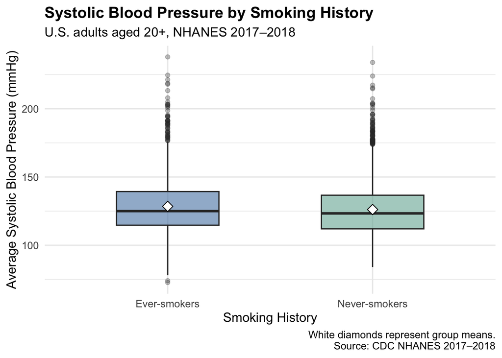

```r
# 4. Create the figure
ggplot(df, aes(x = smoking, y = mean_sbp, fill = smoking)) +
  geom_boxplot(width = 0.5, alpha = 0.55,
               outlier.alpha = 0.3) +
  stat_summary(
    fun = mean,
    geom = "point",
    shape = 23,
    size = 3.5,
    fill = "white",
    color = "black"
  ) +
  scale_fill_manual(
    values = c(
      "Ever-smokers" = "#4477AA",
      "Never-smokers" = "#66AA99"
    )
  ) +
  labs(
    title = "Systolic Blood Pressure by Smoking History",
    subtitle = "U.S. adults aged 20+, NHANES 2017–2018",
    x = "Smoking History",
    y = "Average Systolic Blood Pressure (mmHg)",
    caption = "White diamonds represent group means.\nSource: CDC NHANES 2017–2018"
  ) +
  theme_minimal(base_size = 13) +
  theme(
    legend.position = "none",
    plot.title = element_text(face = "bold")
  )
```

### Data Source and Collection

The data used in this study come from the 2017–2018 National Health and Nutrition Examination Survey (NHANES), conducted by the Centers for Disease Control and Prevention (CDC) through the National Center for Health Statistics (NCHS). NHANES collects information about the health and nutritional status of the U.S. population through household interviews and physical examinations conducted by trained health professionals.

For this study, we use data from three NHANES datasets: Blood Pressure (BPX_J), Smoking – Cigarette Use (SMQ_J), and Demographics (DEMO_J). These datasets are combined using a unique participant identifier.

The data are publicly available through the [CDC NHANES website](https://wwwn.cdc.gov/nchs/nhanes/continuousnhanes/default.aspx?BeginYear=2017).

### Dataset and Key Variables

Our study focuses on U.S. adults aged 20 and older who have available information on both smoking history and systolic blood pressure.

The main variables are **systolic blood pressure** and **smoking history**.

Systolic blood pressure measures the pressure in the arteries when the heart contracts, expressed in millimeters of mercury (mmHg). NHANES records up to three systolic blood pressure readings for each participant (BPXSY1, BPXSY2, and BPXSY3). We calculate the average of the available readings to obtain one blood pressure measurement per participant.

Smoking history is determined by participants’ responses to the question, “Have you smoked at least 100 cigarettes in your entire life?” (SMQ020). Participants who answered “Yes” are classified as *ever-smokers*, while those who answered “No” are classified as *never-smokers*.

Each row in our final dataset represents one adult participant, including their age, smoking history, and average systolic blood pressure.

Because some participants may have missing blood pressure measurements or smoking responses, only participants with the necessary information are included in the analysis.

### Visualization and Observations

Figure 1 compares the distribution of average systolic blood pressure between ever-smokers and never-smokers among 4,996 U.S. adults aged 20 and older in the NHANES 2017–2018 dataset.

Ever-smokers have a slightly higher mean systolic blood pressure (128.47 mmHg) than never-smokers (126.17 mmHg), with an observed difference of approximately 2.30 mmHg. The median values show a similar pattern, at 125 mmHg and 123 mmHg, respectively.

However, the two distributions overlap substantially, and both groups show considerable variation in blood pressure. The standard deviations are approximately 20.6 mmHg for ever-smokers and 19.8 mmHg for never-smokers. Both groups also contain individuals with unusually high blood pressure measurements.

Overall, the visualization suggests a small difference in average systolic blood pressure between the two groups, while highlighting substantial variation within each group. This provides a basis for further investigation into whether the observed difference is also present in the broader U.S. adult population.

# Statistical Analysis

## Parameters of interest

Our research question is: Is there a difference in mean systolic blood pressure between ever-smokers and never-smokers among U.S. adults aged 18 and older?

Let:

mu_E = the population mean systolic blood pressure of ever-smokers.

mu_N = the population mean systolic blood pressure of never-smokers.

The parameter of interest is **mu_E-mu_N**, which is the difference in population means.

## Inference method and hypotheses

We use a **resampling hypothesis test at alpha = 0.05**, **together with a 95% bootstrap confidence interval**, to examine the difference in population mean systolic blood pressure between ever-smokers and never-smokers. We then use a **Welch two-sample t-test and its 95% confidence interval** to assess whether the results are consistent with those obtained from the resampling methods.

So we have H0:mu_E-mu_N = 0, H1:mu_E-mu_N != 0

## Assumption checks

We assess the assumptions of the two-sample T-test using the sample sizes and distributions of systolic blood pressure in each group.

```r
library(tidyverse)
library(haven)
demo <- read_xpt("data/DEMO_J.XPT")
bpx  <- read_xpt("data/BPX_J.XPT")
smq  <- read_xpt("data/SMQ_J.XPT")

# Data tidying
demo_s <- demo %>% select(SEQN, RIDAGEYR)
bpx_s <- bpx %>% select(SEQN, BPXSY1, BPXSY2, BPXSY3, BPXSY4)
smq_s <- smq %>% select(SEQN, SMQ020)

merged <- demo_s %>%
  inner_join(bpx_s, by = "SEQN") %>%
  inner_join(smq_s, by = "SEQN")

long <- merged %>%
  pivot_longer(
    cols = c(BPXSY1, BPXSY2, BPXSY3, BPXSY4),
    names_to = "reading",
    values_to = "sbp"
  ) %>%
  filter(!is.na(sbp))

dat <- long %>%
  group_by(SEQN, RIDAGEYR, SMQ020) %>%
  summarize(
    sbp_mean = mean(sbp),
    n_read = n(),
    .groups = "drop"
  )

dat <- dat %>%
  filter(RIDAGEYR >= 18) %>%
  filter(SMQ020 == 1 | SMQ020 == 2) %>%
  mutate(
    group = ifelse(SMQ020 == 1, "Ever-smoker", "Never-smoker"),
    age = RIDAGEYR
  ) %>%
  select(SEQN, group, sbp_mean, n_read, age)

summary_table <- dat %>%
  group_by(group) %>%
  summarize(
    n = n(),
    mean_sbp = round(mean(sbp_mean), 2),
    sd_sbp = round(sd(sbp_mean), 2)
  )

summary_table
```

```
## # A tibble: 2 × 4
##   group            n mean_sbp sd_sbp
##   <chr>        <int>    <dbl>  <dbl>
## 1 Ever-smoker   2140     128.   20.6
## 2 Never-smoker  3110     125.   19.6
```

```r
# Ever and Never groups
ever <- dat %>% filter(group == "Ever-smoker")
never <- dat %>% filter(group == "Never-smoker")
n_E <- nrow(ever)
n_N <- nrow(never)
obs_diff <- mean(ever$sbp_mean) - mean(never$sbp_mean)
```

Graph 1: Side-by-side Boxplot of Systolic Blood Pressure by Smoking Status

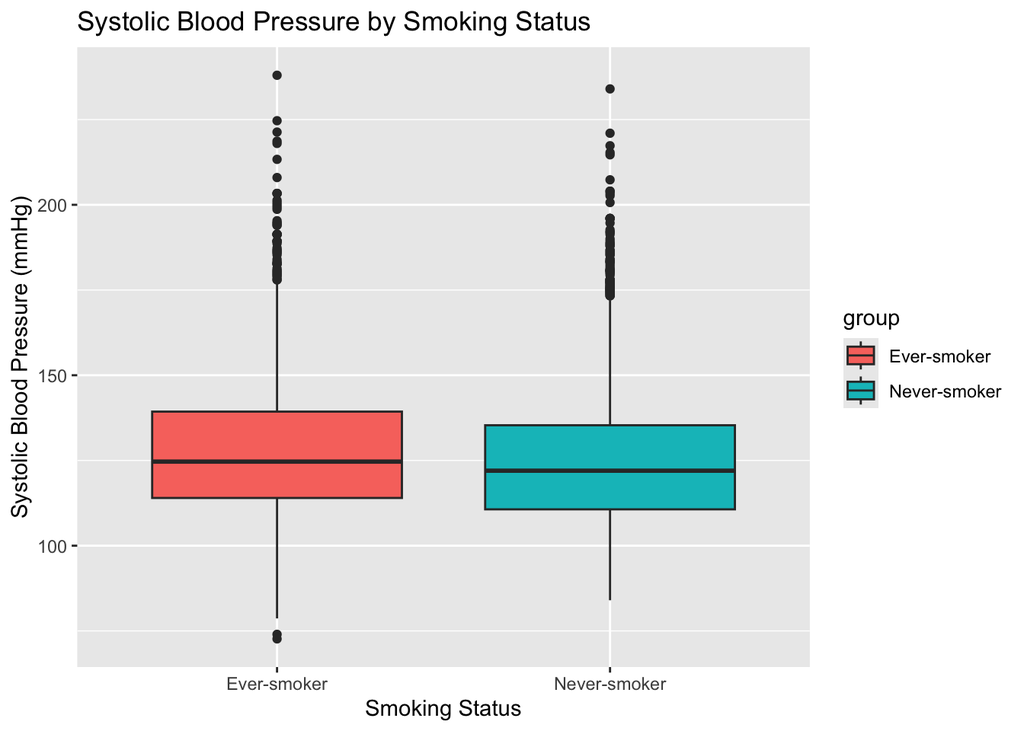

```r
ggplot(dat, aes(x = group, y = sbp_mean, fill = group)) +
  geom_boxplot() +
  labs(title = "Systolic Blood Pressure by Smoking Status",
    x = "Smoking Status",
    y = "Systolic Blood Pressure (mmHg)")
```

Independence: Each participant contributes one average systolic blood pressure value and belongs to only one smoking group. We treat observations as independent, although NHANES uses a complex survey design that is not accounted for in this analysis. This is a limitation.

Normality: Both distributions are right-skewed, with several high-end outliers, including values above 200 mmHg. The sample sizes are 2,140 ever-smokers and 3,110 never-smokers. Under the independence assumption, these large sample sizes allow the Central Limit Theorem to support approximately normal sampling distributions of the means, despite the skewness of the individual observations.

Variance: The sample standard deviations are 20.62 mmHg for ever-smokers and 19.65 mmHg for never-smokers, indicating similar spreads. We use Welch’s two-sample T-test, which does not require equal population variances.

## Resampling hypothesis test

We also conduct a resampling hypothesis test for the difference in population means.

Under H0, the difference in population means is zero. Assuming smoking group labels are exchangeable under the null, we randomly shuffle the labels without replacement, preserving the original group sizes. For each shuffle, we calculate the difference in sample means.

The hypotheses are: H0:mu_E-mu_N = 0, H1:mu_E-mu_N != 0

```r
set.seed(240)

null_diffs <- tibble(
  diff = replicate(10000, {
    shuffled_group <- sample(
      dat$group, size = nrow(dat), replace = FALSE
    )

    mean(dat$sbp_mean[shuffled_group == "Ever-smoker"]) -
      mean(dat$sbp_mean[shuffled_group == "Never-smoker"])
  })
)

pvalue <- mean(abs(null_diffs$diff) >= abs(obs_diff))
pvalue
```

```
## [1] 0
```

```r
obs_diff
```

```
## [1] 3.332232
```

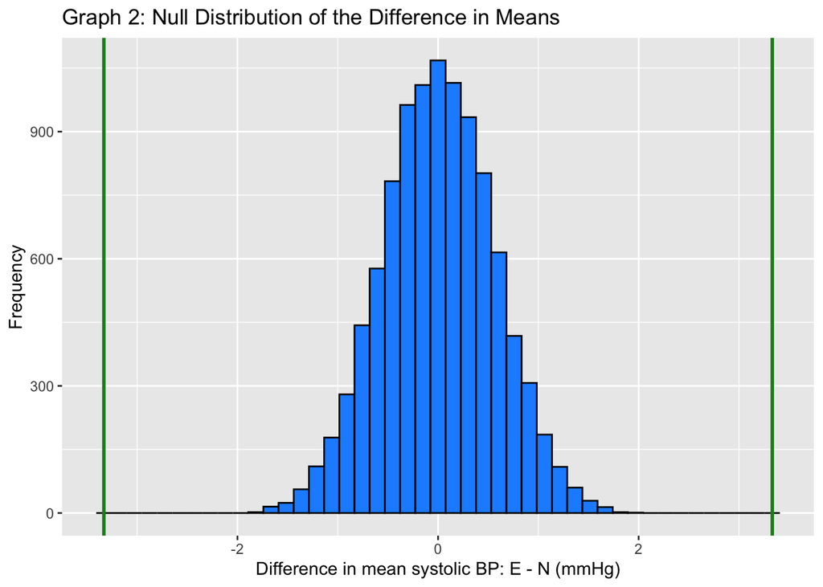

```r
ggplot(null_diffs, aes(x = diff)) +
  geom_histogram(
    bins = 45, fill = "dodgerblue", color = "black"
  ) +
  geom_vline(
    xintercept = c(-abs(obs_diff), abs(obs_diff)),
    color = "forestgreen",
    linewidth = 1
  ) +
  labs(
    title = "Graph 2: Null Distribution of the Difference in Means",
    x = "Difference in mean systolic BP: E - N (mmHg)",
    y = "Frequency"
  )
```

The null distribution is approximately symmetric and centered near zero. The observed difference in sample means is 3.33 mmHg. pvalue is 0 which is smaller than 0.05 significance level, therefore we reject H0, there is evidence shows that there is a difference between the two groups.

## Bootstrap Confidence Interval

We construct a 95% bootstrap confidence interval for the difference in population mean systolic blood pressure.

We independently resample participants with replacement within each smoking group, preserving the original group sizes. For each pair of bootstrap samples, we calculate the difference in sample means.

```r
set.seed(240)

boot_diffs <- tibble(
  ever_mean = replicate(10000,
    mean(sample(ever$sbp_mean, size = n_E, replace = TRUE))
  ),
  never_mean = replicate(10000,
    mean(sample(never$sbp_mean, size = n_N, replace = TRUE))
  ),
  diff = ever_mean - never_mean
)

# 95% bootstrap percentile CI
conf <- 0.95

m_lower <- quantile(boot_diffs$diff, (1 - conf) / 2)
m_upper <- quantile(boot_diffs$diff, 1 - (1 - conf) / 2)

bootstrap_ci <- c(2 * obs_diff - m_upper,2 * obs_diff - m_lower)

bootstrap_ci
```

```
##    97.5%     2.5%
## 2.215902 4.460763
```

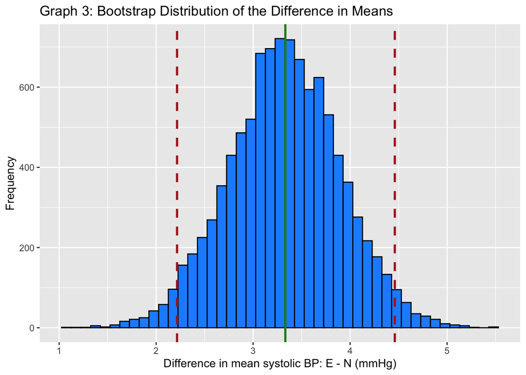

```r
ggplot(boot_diffs, aes(x = diff)) +
  geom_histogram(
    bins = 45, fill = "dodgerblue", color = "black"
  ) +
  geom_vline(
    xintercept = bootstrap_ci,
    color = "firebrick",
    linetype = "dashed",
    linewidth = 1
  ) +
  geom_vline(
    xintercept = obs_diff,
    color = "forestgreen",
    linewidth = 1
  ) +
  labs(
    title = "Graph 3: Bootstrap Distribution of the Difference in Means",
    x = "Difference in mean systolic BP: E - N (mmHg)",
    y = "Frequency"
  )
```

The bootstrap distribution is approximately symmetric and centered near the observed difference of 3.33 mmHg.

The 95% bootstrap confidence interval for mu_E − mu_N is: (2.22, 4.46) mmHg.We have 95% confidence that the population mean systolic blood pressure of ever-smokers is between 2.21 and 4.46 mmHg higher than that of never-smokers, under the assumptions of our analysis.

## Two samples T-test

We perform a Welch two-sample T-test to examine whether the population mean systolic blood pressure differs between ever-smokers and never-smokers. We use this test and its 95% confidence interval to assess whether the results are consistent with those obtained from the resampling methods.

The hypotheses are: H0:mu_E-mu_N = 0, H1:mu_E-mu_N != 0

```r
t.test(ever$sbp_mean,
  never$sbp_mean,
  alternative = "two.sided",
  mu = 0,
  var.equal = FALSE,
  conf.level = 0.95)
```

```
##
##  Welch Two Sample t-test
##
## data:  ever$sbp_mean and never$sbp_mean
## t = 5.864, df = 4450.6, p-value = 4.846e-09
## alternative hypothesis: true difference in means is not equal to 0
## 95 percent confidence interval:
##  2.218175 4.446289
## sample estimates:
## mean of x mean of y
##  128.3226  124.9904
```

Since the p-value is below 0.05, we reject H0. The data provide evidence that mean systolic blood pressure differs between the two groups. The Welch test agrees with the resampling test in rejecting H0 at the 0.05 significance level.

Since the Welch T confidence interval(2.22,4.45) is very similar to the bootstrap confidence interval (2.22, 4.46). Both intervals lie entirely above zero, supporting the conclusion that ever-smokers have higher mean systolic blood pressure than never-smokers.

The results of the Welch two-sample t-test are consistent with those from the resampling hypothesis test and the bootstrap confidence interval.